# IODS course project

**For later use we change the Boston scaled a data frame.**

```r
#Changing the object to data frame
boston_scaled <- as.data.frame(boston_scaled)
```

**In the next step we will investigate how the crime rate in Boston. We first divide the data points for crime rate in the four even categories “low”, “med_low”, “med_high”, “high”.**

```r
#Creating a quantile vector of 'crim' and printing it
bins <- quantile(boston_scaled$crim)
bins
```

```
##           0%          25%          50%          75%         100%
## -0.419366929 -0.410563278 -0.390280295  0.007389247  9.924109610
```

```r
#Creating a categorical variable 'crime' according to the quantiles set in bins
crime <- cut(boston_scaled$crim, breaks = bins, include.lowest = TRUE, labels = c("low","med_low","med_high","high"))

#Let us look at the table of the new factor crime
table(crime)
```

```
## crime
##      low  med_low med_high     high
##      127      126      126      127
```

```r
#Dropping original variable 'crim' from the dataset
boston_scaled <- dplyr::select(boston_scaled, -crim)

#Replacing removed 'crim' with the new categorical value 'crime' to scaled data
boston_scaled <- data.frame(boston_scaled, crime)
```

As we can see from the output the groups are now as even as possible in numbers.

- 0%-25% low - *127*
- 25%-50% med_low - *126*
- 50%-75% med_high - *126*
- 75%-100% high - *127*

**For later clustering investigation of our data we need to divide our data set to a ‘train’ and a ‘test’ sets. 80% of the data will go to the ‘train’ set.**

```r
#The number of rows in the Boston data set
n <- nrow(boston_scaled)

#Choosing randomly 80% of the rows
ind <- sample(n,  size = n * 0.8)

#Creating 'train' set (80% of the rows)
train <- boston_scaled[ind,]

#Creating 'test' set (20% of the rows)
test <- boston_scaled[-ind,]

#Let us save the correct classes from 'test' data
correct_classes <- test$crime

#And remove the crime variable from 'test' data
test <- dplyr::select(test, -crime)
```

**A linear discriminant analysis (LDA) is then carried out on the train set and crating a LDA biplot.**

```r
#A linear discriminant analysis (LDA)
#Crime rate as target variable, all the others (.) as predictor variables
lda.fit <- lda(crime ~ ., data = train)

#Printing the lda.fit object
lda.fit
```

```
## Call:
## lda(crime ~ ., data = train)
##
## Prior probabilities of groups:
##       low   med_low  med_high      high
## 0.2376238 0.2549505 0.2450495 0.2623762
##
## Group means:
##                  zn      indus        chas        nox         rm        age
## low       1.0210524 -0.8437381 -0.19030615 -0.8633139  0.3712177 -0.8886870
## med_low  -0.1123775 -0.2653324  0.03346513 -0.5481752 -0.1525136 -0.2827598
## med_high -0.3729012  0.1932476  0.20489520  0.4152924  0.1227474  0.4822072
## high     -0.4872402  1.0170298 -0.08661679  1.0579083 -0.3621399  0.8089273
##                 dis        rad        tax      ptratio       black       lstat
## low       0.9314301 -0.6792023 -0.7520454 -0.388920608  0.37933438 -0.74611642
## med_low   0.3225303 -0.5537049 -0.4777506 -0.004574031  0.31214069 -0.11147824
## med_high -0.3899130 -0.4494001 -0.3294828 -0.355517034  0.06929825  0.06052171
## high     -0.8373750  1.6390172  1.5146914  0.781811640 -0.76302080  0.87497601
##                 medv
## low       0.44879457
## med_low  -0.02499631
## med_high  0.17303665
## high     -0.68866783
##
## Coefficients of linear discriminants:
##                  LD1          LD2         LD3
## zn       0.057248326  0.855176764 -0.97397457
## indus    0.090462068  0.003050329  0.04173216
## chas    -0.115375472 -0.097134414  0.13677571
## nox      0.368283850 -0.690154247 -1.30692424
## rm      -0.124308934 -0.139004542 -0.16647999
## age      0.177971649 -0.407191497 -0.19071658
## dis      0.004988311 -0.338217378  0.04565038
## rad      3.705109800  1.084210327 -0.23016175
## tax      0.040232478 -0.359779977  0.79728226
## ptratio  0.096289567  0.088014565 -0.18786445
## black   -0.075338707  0.035578346  0.10102166
## lstat    0.226276869 -0.356236105  0.27765804
## medv     0.200241336 -0.494368735 -0.19970414
##
## Proportion of trace:
##    LD1    LD2    LD3
## 0.9550 0.0346 0.0104
```

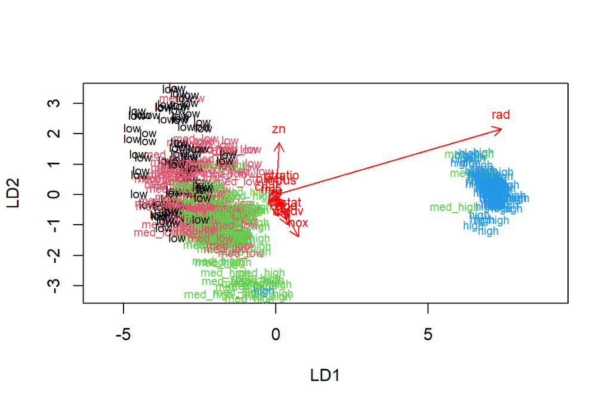

```r
#The function for lda biplot arrows
lda.arrows <- function(x, myscale = 1, arrow_heads = 0.1, color = "red", tex = 0.75, choices = c(1,2)){
  heads <- coef(x)
  arrows(x0 = 0, y0 = 0,
         x1 = myscale * heads[,choices[1]],
         y1 = myscale * heads[,choices[2]], col=color, length = arrow_heads)
  text(myscale * heads[,choices], labels = row.names(heads),
       cex = tex, col=color, pos=3)
}

#Target classes as numeric
classes <- as.numeric(train$crime)

#Plotting the results of lda
plot(lda.fit, dimen = 2, col = classes, pch = classes)
lda.arrows(lda.fit, myscale = 2)
```

**We will try to fit the LDA model to our data to see if we could predict the crime data, based on the other variabels.**

```r
#Prediction of the classes with test data
lda.pred <- predict(lda.fit, newdata = test)

#Cross tabulation of the results
table(correct = correct_classes, predicted = lda.pred$class)
```

```
##           predicted
## correct    low med_low med_high high
##   low       13      16        2    0
##   med_low    4      16        3    0
##   med_high   1      10       13    3
##   high       0       0        0   21
```